# 01 - Data exploration

Airline Customer Satisfaction – Bayesian Learning & Monte Carlo Simulations, 2026

## 1 0. Dataset import

```r
# dataset loading

raw <- read.csv("../data/Airline_customer_satisfaction.csv", stringsAsFactors = FALSE)

# manually set "satisfied" class encoding to 1 (later use)
raw <- raw %>%
  mutate(
    satisfaction   = factor(satisfaction, levels = c("dissatisfied", "satisfied")),
    # even if for this variables their factor won't be relevant during prediction,  is still useful for data exploration
    Class          = factor(Class, levels = c("Eco", "Eco Plus", "Business")),
    Customer.Type  = factor(Customer.Type),
    Type.of.Travel = factor(Type.of.Travel)
  )
```

In order to make the columns easier to manager, we change the column’s names, switching to `camel_case` notation.

```r
new_names <- c(
  "satisfaction", "customer_type", "age", "travel_type", "cabin_class",
  "flight_distance", "seat_comfort", "time_convenient", "food_drink",
  "gate_location", "wifi", "entertainment", "online_support", "ease_booking",
  "onboard_service", "legroom", "baggage", "checkin", "cleanliness",
  "online_boarding", "dep_delay", "arr_delay"
)

names(raw) <- new_names
dim(raw)
```

```
## [1] 129880     22
```

In order to avoid later problems, we immediately check for missing values:

```r
# find and locate missing values
na_counts <- colSums(is.na(raw))
na_counts[na_counts > 0]
```

```
## arr_delay
##       393
```

```r
nrow(raw)
```

```
## [1] 129880
```

```r
raw <- raw %>% filter(!is.na(arr_delay))
raw$row_id <- seq_len(nrow(raw))
nrow(raw)
```

```
## [1] 129487
```

## 2 1. Dataset exploration

Explore general dataset properties.

```r
# general info
str(raw)
```

```
## 'data.frame':    129487 obs. of  23 variables:
##  $ satisfaction   : Factor w/ 2 levels "dissatisfied",..: 2 2 2 2 2 2 2 2 2 2 ...
##  $ customer_type  : Factor w/ 2 levels "Loyal Customer",..: 1 1 1 1 1 1 1 1 1 1 ...
##  $ age            : int  65 47 15 60 70 30 66 10 56 22 ...
##  $ travel_type    : Factor w/ 2 levels "Business travel",..: 2 2 2 2 2 2 2 2 2 2 ...
##  $ cabin_class    : Factor w/ 3 levels "Eco","Eco Plus",..: 1 3 1 1 1 1 1 1 3 1 ...
##  $ flight_distance: int  265 2464 2138 623 354 1894 227 1812 73 1556 ...
##  $ seat_comfort   : int  0 0 0 0 0 0 0 0 0 0 ...
##  $ time_convenient: int  0 0 0 0 0 0 0 0 0 0 ...
##  $ food_drink     : int  0 0 0 0 0 0 0 0 0 0 ...
##  $ gate_location  : int  2 3 3 3 3 3 3 3 3 3 ...
##  $ wifi           : int  2 0 2 3 4 2 2 2 5 2 ...
##  $ entertainment  : int  4 2 0 4 3 0 5 0 3 0 ...
##  $ online_support : int  2 2 2 3 4 2 5 2 5 2 ...
##  $ ease_booking   : int  3 3 2 1 2 2 5 2 4 2 ...
##  $ onboard_service: int  3 4 3 1 2 5 5 3 4 2 ...
##  $ legroom        : int  0 4 3 0 0 4 0 3 0 4 ...
##  $ baggage        : int  3 4 4 1 2 5 5 4 1 5 ...
##  $ checkin        : int  5 2 4 4 4 5 5 5 5 3 ...
##  $ cleanliness    : int  3 3 4 1 2 4 5 4 4 4 ...
##  $ online_boarding: int  2 2 2 3 5 2 3 2 4 2 ...
##  $ dep_delay      : int  0 310 0 0 0 0 17 0 0 30 ...
##  $ arr_delay      : num  0 305 0 0 0 0 15 0 0 26 ...
##  $ row_id         : int  1 2 3 4 5 6 7 8 9 10 ...
```

```r
# check for duplicated rows
cat("Duplicated rows:", sum(duplicated(raw)), "\n")
```

```
## Duplicated rows: 0
```

Now we check variable domain, especially whether all service-quality items lay within the range 0-5.

```r
col_filter = c("age", "flight_distance", "seat_comfort", "time_convenient", "food_drink", "gate_location", "wifi", "entertainment", "online_support", "ease_booking", "onboard_service", "legroom", "baggage", "checkin", "cleanliness", "online_boarding", "dep_delay")

sapply(raw[col_filter], range)
```

```
##      age flight_distance seat_comfort time_convenient food_drink gate_location
## [1,]   7              50            0               0          0             0
## [2,]  85            6951            5               5          5             5
##      wifi entertainment online_support ease_booking onboard_service legroom
## [1,]    0             0              0            0               0       0
## [2,]    5             5              5            5               5       5
##      baggage checkin cleanliness online_boarding dep_delay
## [1,]       1       0           0               0         0
## [2,]       5       5           5               5      1592
```

All quality service variables range over 0-5. The remaining numeric variables also look sane: `age` in [7, 85], `flight_distance` in [50, 6951] miles, except for `arr_delay` due the presence f NaN.

### 2.1 1.1 Target variable class balance

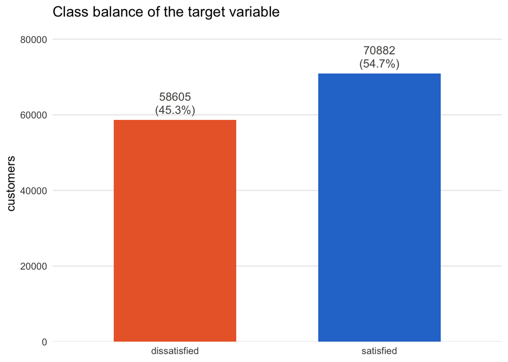

```r
# check and lot target class balance

pal <- c(dissatisfied = "#eb6834", satisfied = "#2a78d0")

bal <- raw %>%
  count(satisfaction) %>%
  mutate(share = n / sum(n),
         satisfaction = factor(satisfaction, levels = c("dissatisfied", "satisfied")))

ggplot(bal, aes(satisfaction, n, fill = satisfaction)) +
  geom_col(width = 0.6, show.legend = FALSE) +
  geom_text(aes(label = sprintf("%d\n(%.1f%%)", n, 100 * share)),
            vjust = -0.3, size = 4, colour = "#52514e", lineheight = 0.95) +
  scale_fill_manual(values = pal) +
  scale_y_continuous(expand = expansion(mult = c(0, 0.18))) +
  labs(title = "Class balance of the target variable",
       x = NULL, y = "customers") +
  theme_minimal(base_size = 12) +
  theme(panel.grid.major.x = element_blank(), panel.grid.minor = element_blank())
```

The response is close to balanced (54.7% satisfied), therefore we won’t need something more complex than a Bernoulli+logistic regression model.

### 2.2 1.2 Boxplots

```r
# we modify categorical variables in order to show them in the boxplots and correlation matrix

num.raw = raw
cat_vars = names(num.raw)[!sapply(num.raw, is.numeric)]

mappings <- lapply(num.raw[cat_vars], levels)
num.raw[cat_vars] <- lapply(num.raw[cat_vars], as.integer)
```

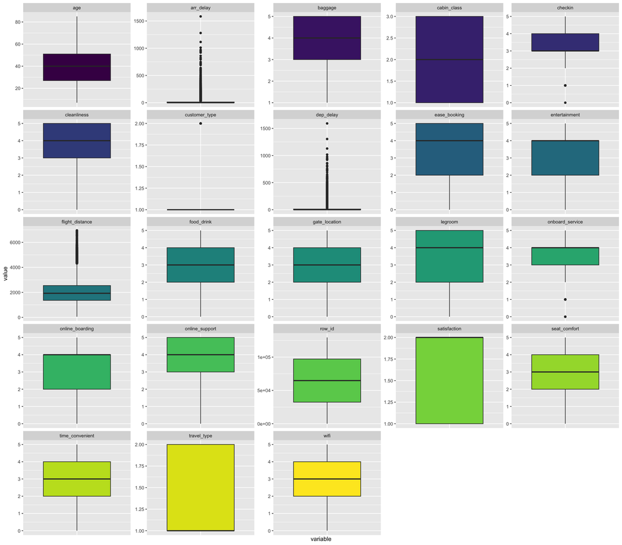

```r
num.raw %>%
  select(where(is.numeric)) %>%
  pivot_longer(everything(), names_to = "variable", values_to = "value") %>%
  ggplot(aes(x = variable, y = value, fill = variable)) +
  geom_boxplot(show.legend = FALSE) +
  facet_wrap(~ variable, scales = "free") +
  scale_fill_viridis_d() +
  theme(axis.text.x = element_blank(), axis.ticks.x = element_blank())
```

### 2.3 1.2.1 Quality of Service indicators by satisfaction

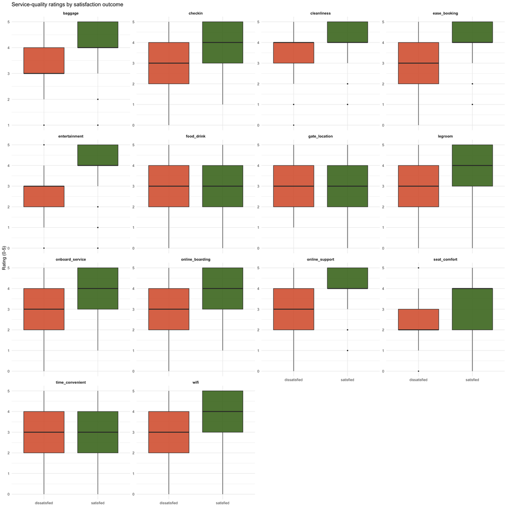

```r
qs_vars <- c("seat_comfort", "time_convenient", "food_drink", "gate_location", "wifi", "entertainment", "online_support", "ease_booking", "onboard_service", "legroom", "baggage", "checkin", "cleanliness", "online_boarding")

raw %>%
  select(satisfaction, all_of(qs_vars)) %>%
  pivot_longer(-satisfaction, names_to = "item", values_to = "rating") %>%
  ggplot(aes(x = satisfaction, y = rating, fill = satisfaction)) +
  geom_boxplot(outlier.size = 0.4, alpha = 0.85) +
  facet_wrap(~ item, ncol = 4, scales = "free_y") +
  scale_fill_manual(values = c("dissatisfied" = "#D85A30", "satisfied" = "#3B6D11")) +
  labs(title = "Service-quality ratings by satisfaction outcome",
       x = NULL, y = "Rating (0-5)") +
  theme_minimal(base_size = 9) +
  theme(legend.position = "none",
        axis.text.x = element_text(angle = 0),
        strip.text = element_text(face = "bold", size = 7.5))
```

The customer satisfaction per item follows the same pattern expressed by the correlation between the QS variable and the respective correlation (see below). Generally speaking we can see that the higher the customer satisfaction the higher the QS was.

### 2.4 1.3 Full correlation heatmap

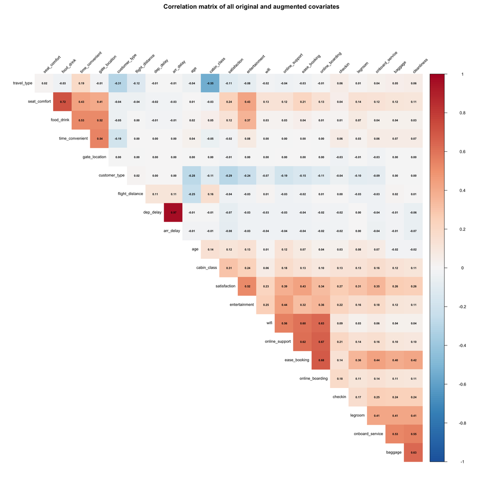

```r
corr_mat = cor(num.raw[, !names(num.raw) == "row_id"])

corrplot(corr_mat, method = "color", type = "upper", order = "hclust",
         col = colorRampPalette(rev(brewer.pal(9, "RdBu")))(200),
         tl.col = "black", tl.srt = 45, tl.cex = 0.75,
         addCoef.col = "black", number.cex = 0.55,
         diag = FALSE,
         title = "Correlation matrix of all original and augmented covariates",
         mar = c(0, 0, 2, 0))
```

### 2.5 1.3.1 Quality service correlation

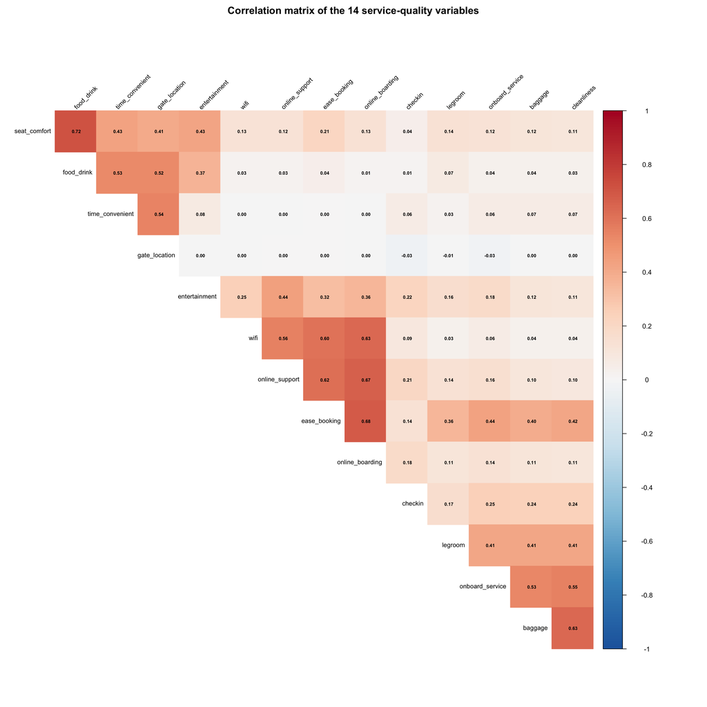

```r
# focus on the correlation between Quality of Service variables

# re-defining them for clarity
qs_vars <- c("seat_comfort", "time_convenient", "food_drink", "gate_location", "wifi", "entertainment", "online_support", "ease_booking", "onboard_service", "legroom", "baggage", "checkin", "cleanliness", "online_boarding")


qs_corr <- cor(num.raw[, qs_vars], use = "pairwise.complete.obs")

corrplot(qs_corr, method = "color", type = "upper", order = "hclust",
         col = colorRampPalette(rev(brewer.pal(9, "RdBu")))(200),
         tl.col = "black", tl.srt = 45, tl.cex = 0.75,
         addCoef.col = "black", number.cex = 0.55,
         diag = FALSE,
         title = "Correlation matrix of the 14 service-quality variables",
         mar = c(0, 0, 2, 0))
```

from the quality of service correlation matrix we can distinguish 3 clusters of variables.

```r
cluster_range <- function(items) {
  sub <- qs_corr[items, items]
  vals <- sub[upper.tri(sub)]
  sprintf("%.2f-%.2f", min(vals), max(vals))
}


cluster_booking  <- c("wifi", "entertainment", "online_support", "ease_booking")

cluster_onboard  <- c("onboard_service", "legroom", "baggage")

cluster_catering <- c("seat_comfort", "food_drink", "gate_location")

r_booking  <- cluster_range(cluster_booking)
r_onboard  <- cluster_range(cluster_onboard)
r_catering <- cluster_range(cluster_catering)

r_booking
```

```
## [1] "0.25-0.62"
```

```r
r_onboard
```

```
## [1] "0.41-0.53"
```

```r
r_catering
```

```
## [1] "0.41-0.72"
```

### 2.6 1.4 Structural zeros in quality of service variables

```r
zero_share <- sort(sapply(raw[, qs_vars], function(x) mean(x == 0)),
                    decreasing = TRUE)

knitr::kable(
  data.frame(item = names(zero_share), zero_share = round(zero_share, 3)),
  row.names = FALSE, col.names = c("Service item", "Share of rows = 0"),
  caption = "Share of rows recording a 0 rating, by service item"
)
```

Share of rows recording a 0 rating, by service item

| Service item | Share of rows = 0 |
| --- | --- |
| time_convenient | 0.051 |
| food_drink | 0.046 |
| seat_comfort | 0.037 |
| entertainment | 0.023 |
| legroom | 0.003 |
| wifi | 0.001 |
| ease_booking | 0.000 |
| online_boarding | 0.000 |
| onboard_service | 0.000 |
| cleanliness | 0.000 |
| gate_location | 0.000 |
| online_support | 0.000 |
| checkin | 0.000 |
| baggage | 0.000 |

We flag, but do not model, the items with a non-trivial zero share (above 2%) as a single per-row indicator, to be used later only as a robustness check

```r
zero_candidates <- names(zero_share)[zero_share > 0.02]

raw <- raw %>%
  mutate(structural_zero_flag = if_any(all_of(zero_candidates), ~ .x == 0))

n_flagged <- sum(raw$structural_zero_flag)
n_flagged
```

```
## [1] 10222
```

## 3 2. Data augmentation

Before any exploration we show some changes we’ve done to the dataset, avoiding to show irrelevant information.

### 3.1 2.1 Decorrelating Departure and Arrival delay

```r
delay_cor <- cor(raw$dep_delay, raw$arr_delay, use = "complete.obs")
n_missing_arr <- sum(is.na(raw$arr_delay))
```

`Departure Delay` and `Arrival Delay` correlate at 0.965: using both raw would be close to duplicating one variable.

We tought about two solutions:

- taking the difference between them and accounting for the “mid-fly delay”
- enriching the previous concept and regress `Arrival Delay` on `Departure Delay` and keep the **residual** as a second covariate – by construction uncorrelated with `Departure Delay`, and interpretable as “minutes gained or lost in the air relative to what the departure delay alone would predict”:

```r
# exploring the

delay_fit <- lm(arr_delay ~ dep_delay, data = raw)
raw$arr_delay_res <- residuals(delay_fit)

check_cor <- cor(raw$dep_delay, raw$arr_delay, use = "complete.obs")
```

The fitted relationship is Arrival $\approx$ 0.76 $+$ 0.979 $\times$ Departure (R$^2$ = 0.932).

```r
raw$midfly_delay <- raw$arr_delay - raw$dep_delay
```

### 3.2 2.1 Adjust for skewnees

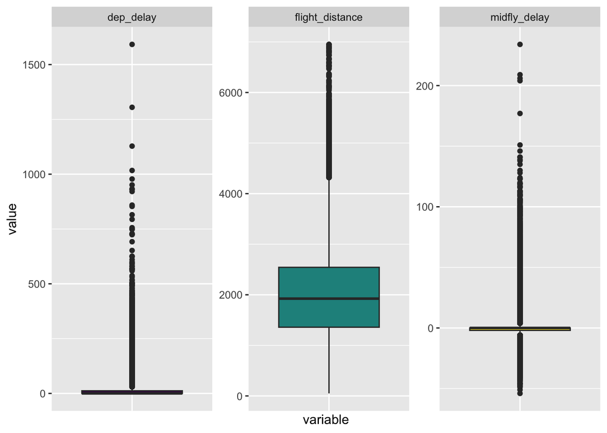

```r
raw[, c("flight_distance", "dep_delay", "midfly_delay")] %>%
  select(where(is.numeric)) %>%
  pivot_longer(everything(), names_to = "variable", values_to = "value") %>%
  ggplot(aes(x = variable, y = value, fill = variable)) +
  geom_boxplot(show.legend = FALSE) +
  facet_wrap(~ variable, scales = "free") +
  scale_fill_viridis_d() +
  theme(axis.text.x = element_blank(), axis.ticks.x = element_blank())
```

From the boxplots we can see that covariates `flight distance`, `departure delay' and`midfly delay` are skew. So we apply a log-transformation and we check the results to verify if the transformation is worthy or not.

```r
skew <- function(x) { x <- x[!is.na(x)]; m <- mean(x); s <- sd(x); mean(((x - m) / s)^3) }

signedLogArr <- sign(raw$midfly_delay) * log1p(abs(raw$midfly_delay))

skew_tbl <- data.frame(
  variable = c("Flight Distance", "log1p(Flight Distance)",
               "Departure Delay", "log1p(Departure Delay)",
               "Midflight Delay", "signed-log(Midflight delay)"
               ),
  skewness = round(c(
    skew(raw$flight_distance), skew(log1p(raw$flight_distance)),
    skew(raw$dep_delay), skew(log1p(raw$dep_delay)),
    skew(raw$midfly_delay), skew(signedLogArr)
    ), 3)
)
knitr::kable(skew_tbl)
```

| variable | skewness |
| --- | --- |
| Flight Distance | 0.466 |
| log1p(Flight Distance) | -1.599 |
| Departure Delay | 6.853 |
| log1p(Departure Delay) | 0.919 |
| Midflight Delay | 2.941 |
| signed-log(Midflight delay) | 0.234 |

```r
raw$log_mid_delay <- signedLogArr
raw$log_dep_delay <- log1p(raw$dep_delay)
```

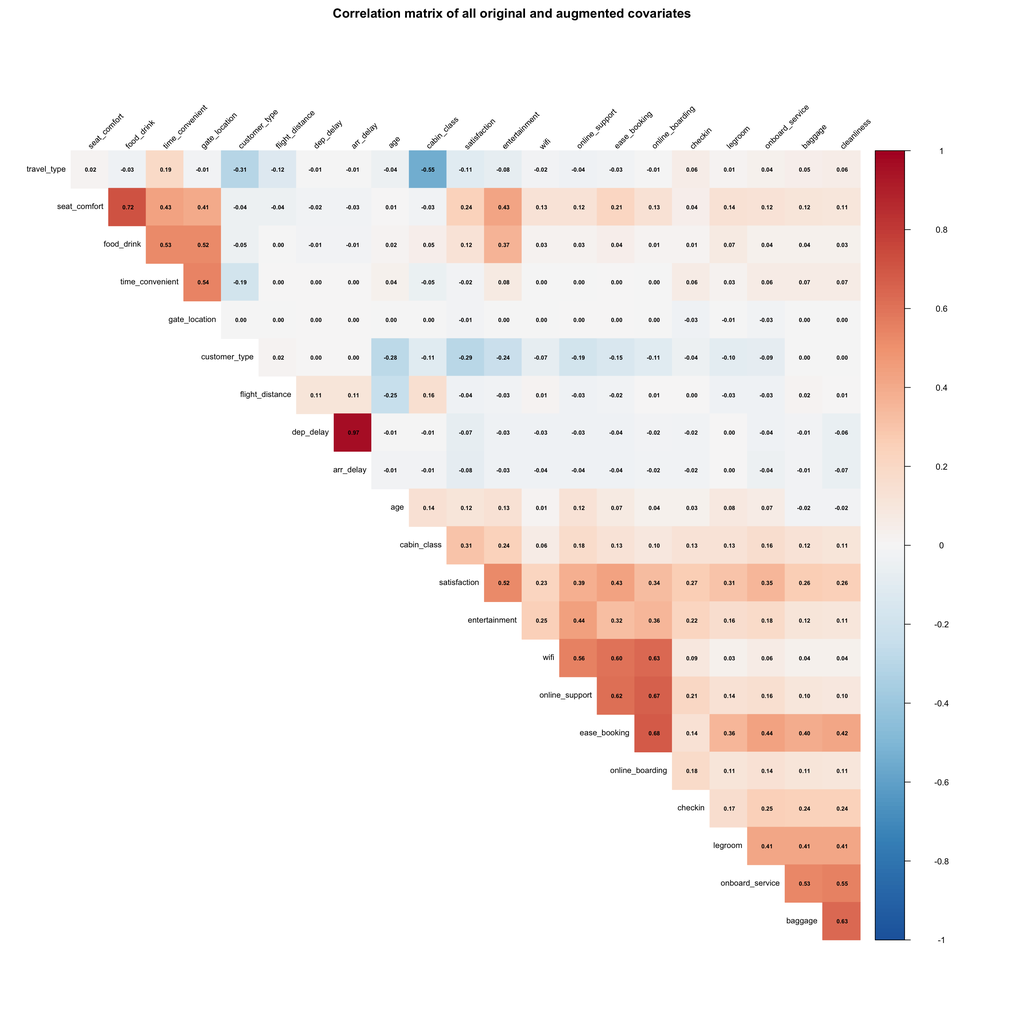

```r
new_corr_mat = cor(num.raw[, !names(num.raw) == "row_id"])
# arr_delay_res is excluded due problems during the plotting

corrplot(new_corr_mat, method = "color", type = "upper", order = "hclust",
         col = colorRampPalette(rev(brewer.pal(9, "RdBu")))(200),
         tl.col = "black", tl.srt = 45, tl.cex = 0.75,
         addCoef.col = "black", number.cex = 0.55,
         diag = FALSE,
         title = "Correlation matrix of all original and augmented covariates",
         mar = c(0, 0, 2, 0))
```

## 4 3. Data stratification, split and storage

In the remaining part we stratify the dataset for the model, we split it and we store it for later use.

### 4.1 3.1 Data stratification and split

The brief describes a curated 1,000-row file; we have the full 129,487-row source. We draw a stratified training subsample of $n \approx 1{,}200$, and we stratify it to reflect categorical variable classes proportions.

```r
cat_vars <- c("satisfaction", "customer_type", "travel_type", "cabin_class")

lapply(raw[cat_vars], function(x) round(prop.table(table(x)), 3))
```

```
## $satisfaction
## x
## dissatisfied    satisfied
##        0.453        0.547
##
## $customer_type
## x
##    Loyal Customer disloyal Customer
##             0.817             0.183
##
## $travel_type
## x
## Business travel Personal Travel
##           0.691           0.309
##
## $cabin_class
## x
##      Eco Eco Plus Business
##    0.449    0.072    0.479
```

Basically all categorical variables need to be stratified.

```r
set.seed(123)

strata <- interaction(raw$satisfaction, raw$cabin_class, raw$customer_type, raw$travel_type, drop = TRUE)
train_idx <- createDataPartition(y = strata, p = 1200 / nrow(raw), list = FALSE)

train_df <- raw[train_idx, ]
test_df  <- raw[-train_idx, ]
```

Training subsample: 1213 rows. Held-out test set: 128,274 rows.

```r
compare_tbl <- function(var) {
  full  <- prop.table(table(raw[[var]]))
  train <- prop.table(table(train_df[[var]]))
  round(cbind(full = full, train = train), 3)
}

cat("Satisfaction proportions (full data vs. training subsample):\n")
```

```
## Satisfaction proportions (full data vs. training subsample):
```

```r
print(compare_tbl("satisfaction"))
```

```
##               full train
## dissatisfied 0.453 0.454
## satisfied    0.547 0.546
```

```r
cat("\nClass proportions (full data vs. training subsample):\n")
```

```
##
## Class proportions (full data vs. training subsample):
```

```r
print(compare_tbl("cabin_class"))
```

```
##           full train
## Eco      0.449 0.448
## Eco Plus 0.072 0.075
## Business 0.479 0.477
```

```r
cat("\nCustomer Type proportions (full data vs. training subsample):\n")
```

```
##
## Customer Type proportions (full data vs. training subsample):
```

```r
print(compare_tbl("customer_type"))
```

```
##                    full train
## Loyal Customer    0.817 0.815
## disloyal Customer 0.183 0.185
```

### 4.2 3.2 Dataset storage

```r
saveRDS(raw, "../data/airline_full_clean.rds")
write.csv(train_df, "../data/airline_train_n1200.csv", row.names = FALSE)
write.csv(test_df,  "../data/airline_test_holdout.csv", row.names = FALSE)
```